# AI Foundations: AII 600

## Normal Distribution - Variance Parameter

By changing the variance parameter $\sigma^2$, we change the “fatness” of the bell curve

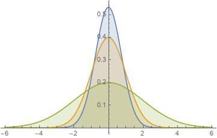

Normal Distribution - Variance

## Normal Distribution - Real Data

Chicago Wind Speed (2007-2014) data on a log scale seem to be well described by the Normal distribution

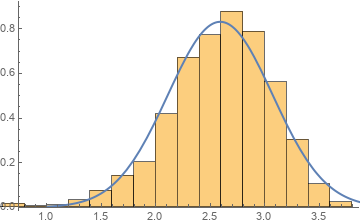

Normal Distribution - Wind Data

## `pnorm` and `qnorm`

We can find probabilities and quantiles in **R**. Here are the important values

```r
>pnorm(2.58)
[1] 0.9950
>pnorm(1.96)
[1] 0.9750
>pnorm(1.64)
[1] 0.9499
```

`qnorm` is the inverse of `pnorm`. Simulation `rnorm`. `N=1000, x=rnorm(N,0,1), p=sum(x<1.96)/N`

## Normal Distribution with General Mean and Variance

Here are two useful facts: If $X \sim \text{N}(\mu, \sigma^2)$, then

$$\begin{align*}
P(\mu - 2.58 \sigma < X < \mu + 2.58 \sigma) =& 0.99 \\
P(\mu - 1.96 \sigma < X < \mu + 1.96 \sigma) =& 0.95
\end{align*}$$

- The chance that $X$ will be within $2.58 \sigma$ of its mean is $99$%, and the chance that it will be within $2\sigma$ of its mean is about $95$%.

## Pictorially

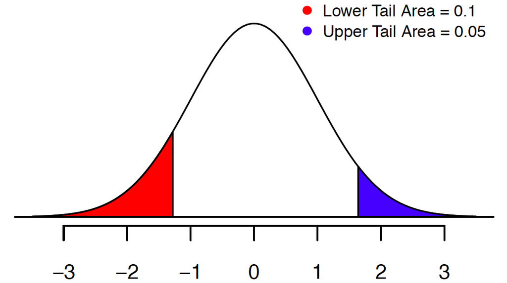

Normal Distribution Tails

Examples of upper and lower tail areas. The lower tail area of $0.1$ is at $z = -1.28$. The upper tail area of $0.05$ is at $z=1.64$

## Example: The Crash

**How extreme was the 1987 crash of $-21.76$%?**

1. Prior to the October, 1987 crash SP500 monthly returns were $1.2$% with a risk/volatility of $4.3$%
   $$X \sim N(0.012, 0.043^2)$$
   **Standardize:**
   $$Z =\frac{X-\mu}{\sigma} = \frac{X - 0.012}{0.043} \sim N(0,1)$$
2. Calculate the observed $Z$:
   $$Z = \frac{-0.2176 - 0.012}{0.043} = -5.34$$
   That’s a **$5$-sigma event!**

## Example: The Crash - Model Validation

We assumed returns follow normal distribution. Using an inaccurate model can lead to inaccurate results.

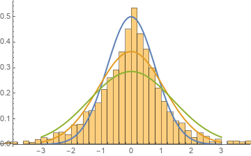

S&P 500 Returns vs Normal

## Normal as Approximation to Binomial

A real estate firm offers a free trip. Of those who accept, 5% buy a property. If the firm brings $n=1000$ people, what is $P(X \ge 60)$ for $X\sim\mathrm{Binomial}(1000, 0.05)$?

Mean $\mu=np=50$, $\sigma=\sqrt{np(1-p)}=\sqrt{47.5}=6.89$. Continuity correction:
$$Z=\frac{59.5-50}{6.89}=1.38, \qquad P(Z\ge 1.38)\approx 0.084$$

In R the exact value is a one-liner, and the approximation is there to be checked, not to replace it:

```r
1 - pbinom(59, 1000, 0.05)   # 0.087
1 - pnorm(59.5, 50, sqrt(47.5))
```